# Lab 7

## Question 4

1. Use a hierarchical clustering approach to examine clustering in the x, y coordinates and the elevation column in your data B) plot the dendrogram. C) evaluate the number of clusters that may be appropriate D) plot the clustered data using “fviz_cluster” E) assign your selected clusters back to your original dataset and summarize the data.

```r
## computing dissimilarity matrix
clusterdata$elev_m <- as.numeric(clusterdata$elev_m)
scale_clusterdata_dist <- dist(scale(cbind(st_coordinates(clusterdata), clusterdata$elev_m)), method = "euclidean")

# Hierarchical clustering using single linkage
hcluster_sing <- hclust(scale_clusterdata_dist, method = "single" )
# Hierarchical clustering using Complete Linkage
hcluster_comp <- hclust(scale_clusterdata_dist, method = "complete" )
# Hierarchical clustering using average Linkage
hcluster_avg <- hclust(scale_clusterdata_dist, method = "average" )
# Hierarchical clustering using ward.D Linkage
hcluster_ward <- hclust(scale_clusterdata_dist, method = "ward.D" )
```

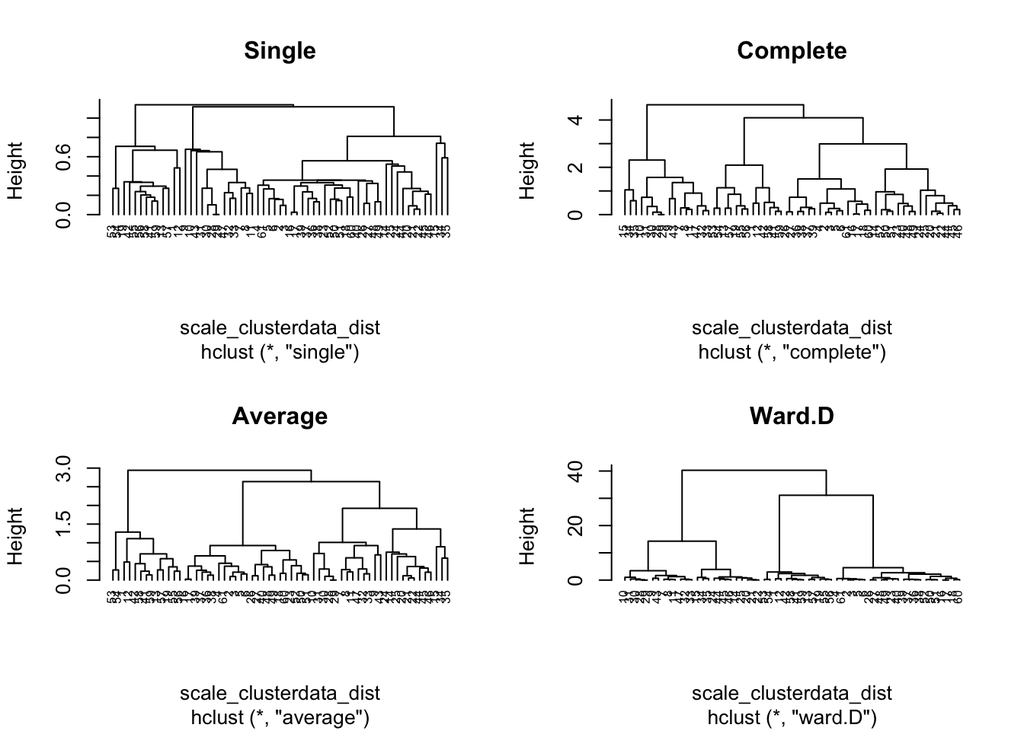

```r
## plotting dendrograms
par(mfrow = c(2,2))
plot(hcluster_sing, cex = 0.6, hang = -1, main = 'Single')
plot(hcluster_comp, cex = 0.6, hang = -1, main = 'Complete')
plot(hcluster_avg, cex = 0.6, hang = -1, main = 'Average')
plot(hcluster_ward, cex = 0.6, hang = -1, main = 'Ward.D')
```

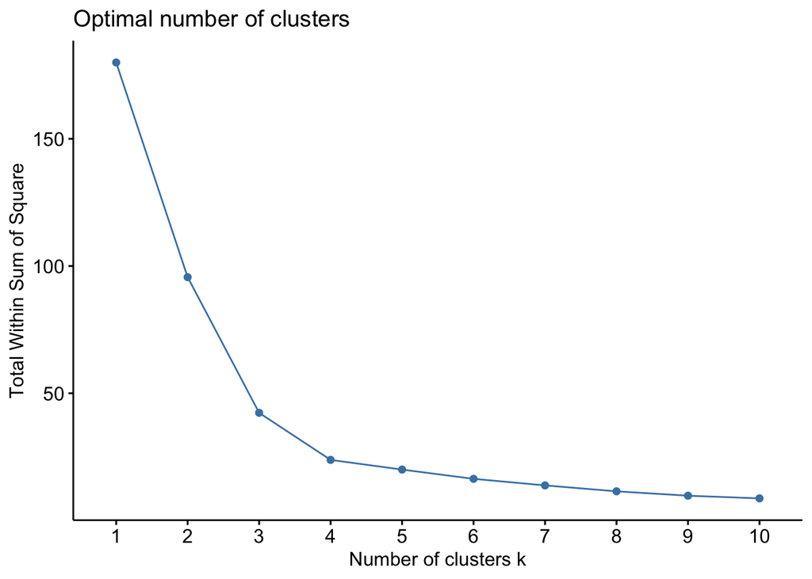

```r
## Evaluating number of clusters
tst1 <-  fviz_nbclust(x=scale(cbind(st_coordinates(clusterdata), clusterdata$elev_m)), FUNcluster= hcut, method = "wss")
tst2 <-  fviz_nbclust(x=scale(cbind(st_coordinates(clusterdata), clusterdata$elev_m)), FUNcluster= hcut, method = "silhouette")
tst3 <-  fviz_nbclust(x=scale(cbind(st_coordinates(clusterdata), clusterdata$elev_m)), FUNcluster= hcut, method = "gap_stat", nboot=10)
tst1
```

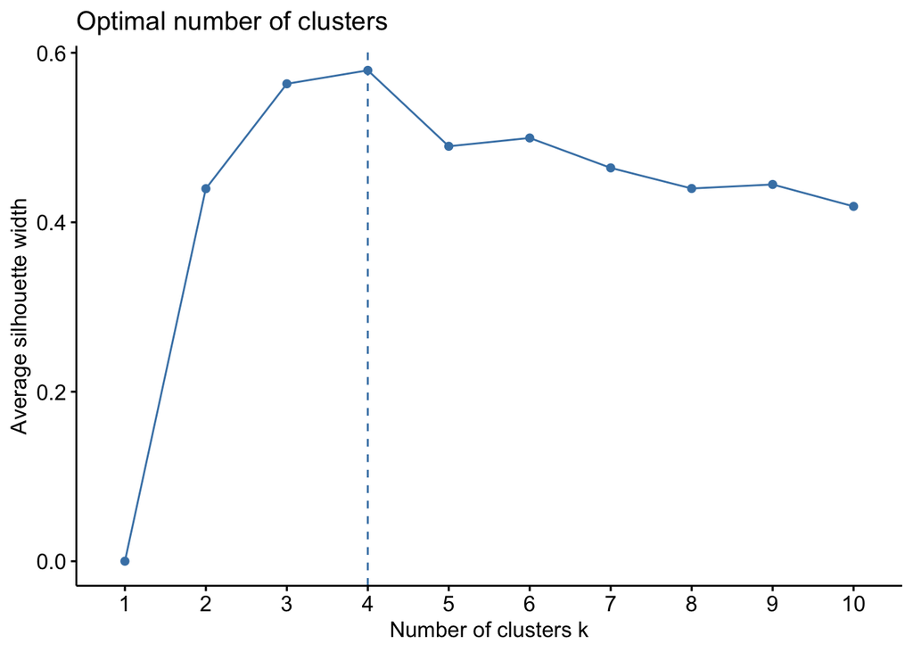

```r
tst2
```

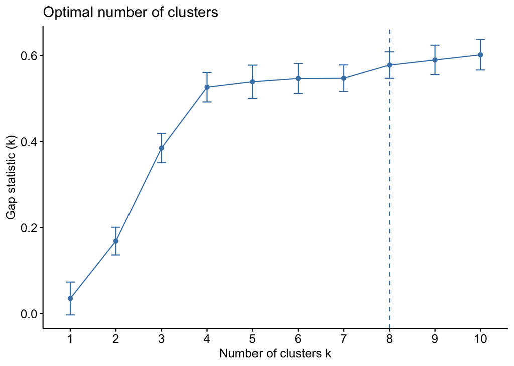

```r
tst3
```

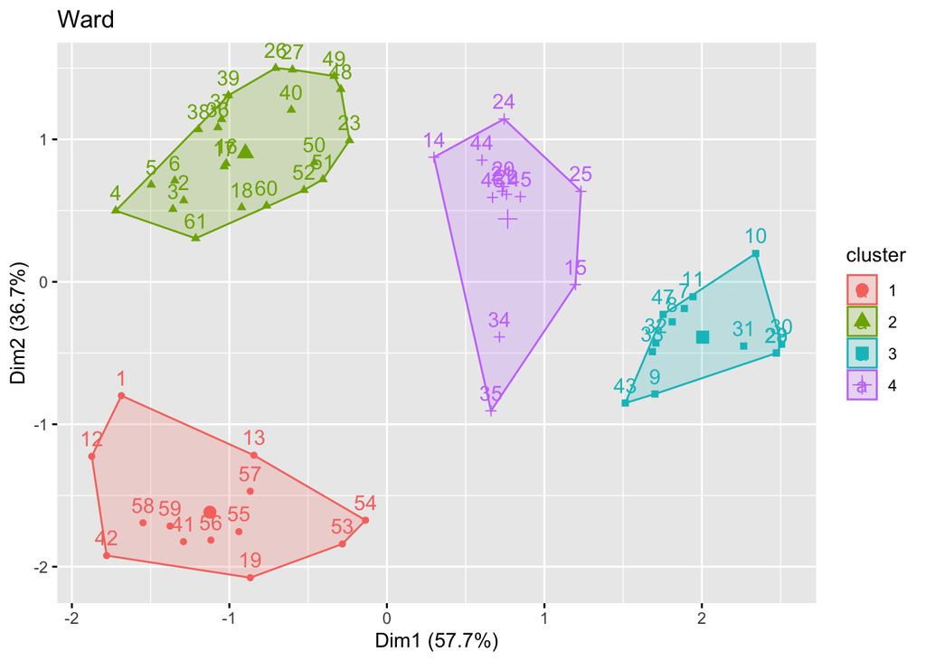

```r
## Based on these plots, 4 clusters appears to be an appropriate number of clusters. In the Silhouette chart, the average silhouette width maximizes at 4.

## plotting with fviz_cluster
hcluster_ward_4k <- cutree(hcluster_ward, k = 4)
fviz_cluster(list(data = scale(cbind(st_coordinates(clusterdata), clusterdata$elev_m)), cluster = hcluster_ward_4k), main = 'Ward')
```

```r
## Assigning Clusters back to Original Dataset
clusterdata$cluster <- as.factor(cutree(hcluster_ward, k = 4))
summary(clusterdata)
```

```
##    NEAR_DIST         perp_dista      elev_m           sex
##  Min.   : 0.5616   Min.   :0.0   Min.   : 595.0   Length:61
##  1st Qu.: 2.0725   1st Qu.:1.0   1st Qu.: 785.0   Class :character
##  Median : 4.5183   Median :2.0   Median : 911.0   Mode  :character
##  Mean   : 8.2001   Mean   :2.6   Mean   : 929.3
##  3rd Qu.:11.6035   3rd Qu.:3.9   3rd Qu.:1097.0
##  Max.   :36.0164   Max.   :9.6   Max.   :1265.0
##             geom    cluster
##  POINT        :61   1:13
##  epsg:26911   : 0   2:23
##  +proj=utm ...: 0   3:13
##                     4:12
##
##
```

## Question 5.

Given the papers by Abas 2008 and Chen et al. 2005 - what conclusions might you make about which clustering level is best? Do these two papers show concordant conclusions? Why or Why not?

Answer: The papers both evaluate the effectiveness of hierarchical clustering compared to K-means clustering. Given Abas 2008’s conclusions on the performance of hierarchical clustering improving as the value of k increases, it could potentially be reasonable to use a higher level of clustering when working with hierarchical methods. However, given that our dataset for this lab is fairly small, Abas 2008’s conclusion about hierarchical clustering showing good results with small datasets means we can probably stick with the level of clustering that I chose in question 4. The 2 papers do show similar general conclusions in that they both describe K-means clustering as demonstrating better performance than hierarchical clustering. Abas 2008 differs largely by taking its conclusions further and describing in greater specificity which method is typically better depending on the size of the dataset someone is working with, with larger datasets typically being better suited to K-means clustering.

## Question 6 - Graduate Students Yes - Undergraduates XC

Using the ClustGeo library evaluate and produce a geographically constrained cluster with the same k that you resolved in Question 4.

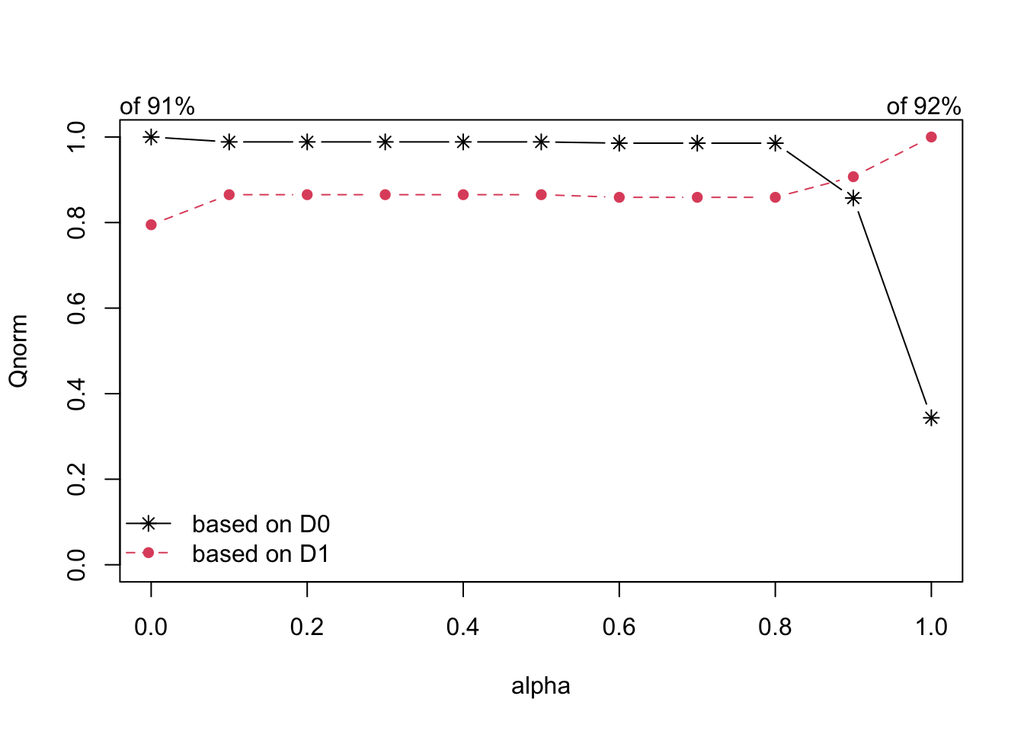

```r
## borrowing Ken's function to explore alpha choices
range.alpha<-seq(0,1,0.1)
fca <- function(d1,d2,k){
  tmp <- choicealpha(d1, d2, range.alpha,
              k, graph = FALSE)
}

## preparing data for alpha checking
clusterdata_geo <- cbind(unlist(lapply(st_geometry(clusterdata),`[`,1)), unlist(lapply(st_geometry(clusterdata),`[`,2)))
clusterdata_geo_dist <-  get_dist(clusterdata_geo, stand=T)

clusterdata_df <- st_drop_geometry(clusterdata)[,'elev_m']
clusterdata_df_dist <- get_dist(clusterdata_df, stand=T)

## checking alpha
alphacheck <- fca(d1=clusterdata_geo_dist, d2=clusterdata_df_dist, k=4)
plot(alphacheck, norm = TRUE)
```

```r
alphacheck$Q
```

```
##                  Q0        Q1
## alpha=0   0.9121716 0.7346994
## alpha=0.1 0.9017035 0.7996615
## alpha=0.2 0.9017035 0.7996615
## alpha=0.3 0.9017035 0.7996615
## alpha=0.4 0.9017035 0.7996615
## alpha=0.5 0.9017035 0.7996615
## alpha=0.6 0.8990574 0.7939527
## alpha=0.7 0.8990574 0.7939527
## alpha=0.8 0.8990574 0.7939527
## alpha=0.9 0.7820365 0.8384836
## alpha=1   0.3134151 0.9243034
```

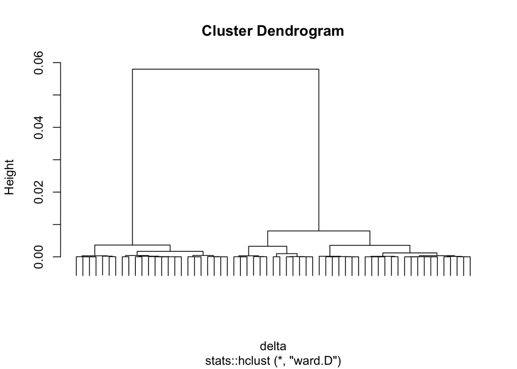

```r
## creating geocluster
geocluster <- hclustgeo(clusterdata_geo_dist,clusterdata_df_dist, alpha = 0.9)
plot(geocluster, labels=F)
```

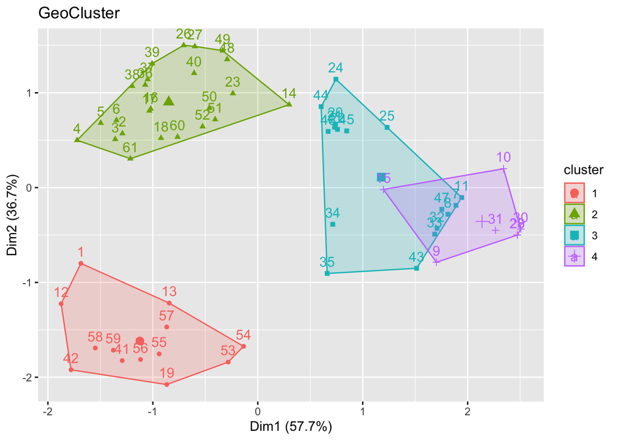

```r
## assigning clusters back to original data
geocluster_k4 <- cutree(geocluster,k=4)
clusterdata$geocluster_k4 <- geocluster_k4
## plotting clusters
gcp <- fviz_cluster(list(data = scale(cbind(st_coordinates(clusterdata), clusterdata$elev_m)), cluster = geocluster_k4), main = 'GeoCluster')
gcp
```